# Rapport ACM et CAH sur les races canines

Lila HAMEL

# Objectif

Nous disposons de données qui mesurent un ensemble de caractéristiques d’une race canine, et ce pour $27$ différentes races.

Le but est d’analyser la variable **FONCTION** (compagnie, chasse, utilité) en fonction des caractéristiques **physiques** (taille, poids, vélocité) et psychiques (intelligence comprise comme aptitude au dressage, affection, agressivité) qu’elle présente.

Nous allons faire une analyse de composantes multiples qui va permettre un recodage numérique des données qualitatives pour ensuite appliquer une classification ascendante hiérarchique. Nous pourrons alors regrouper les races dans des clusters en mesurant leur degré de similitude.

# Variables illustratives et actives

Ici, les variables actives sont les modalités X1 = Taille, X2 = Poids, X3 = Vélocité, X4 = Intelligence, X5 = Affection, X6 = Agressivité, et ont chacune trois modalités: faible (- ou 1), moyen (+ ou 2), fort (++ ou 3).

La variable X7 = Fonction, est illustrative et a aussi trois modalités (compagnie = co, chasse = ch, utilité = ut).

# Visualisation des données

Aperçu des données races canines

|  | Taille | Poids | Vélocité | Intelligence | Affection | Agressivité | Fonction |
| --- | --- | --- | --- | --- | --- | --- | --- |
| BEAU | 3 | 2 | 3 | 3 | 2 | 2 | 3 |
| BASS | 1 | 1 | 1 | 1 | 1 | 2 | 2 |
| B.AL | 3 | 2 | 3 | 3 | 2 | 2 | 3 |
| BOXE | 2 | 2 | 2 | 2 | 2 | 2 | 1 |
| BULD | 1 | 1 | 1 | 2 | 2 | 1 | 1 |
| BULM | 3 | 3 | 1 | 3 | 1 | 2 | 3 |

# Analyse de l’ACM

l’ACM va nous aider à représenter les similitudes entre les races canines qu’on appelera **individus**, et les similitudes entre les modalités des variables qu’on appelera **variables**.

### Analyse des valeurs propres

| Axes | eigenvalue | variance.percent | cumulative.variance.percent |
| --- | --- | --- | --- |
| Dim.1 | 0.488 | 29.255 | 29.255 |
| Dim.2 | 0.386 | 23.140 | 52.396 |
| Dim.3 | 0.221 | 13.244 | 65.639 |
| Dim.4 | 0.164 | 9.868 | 75.508 |
| Dim.5 | 0.149 | 8.920 | 84.427 |
| Dim.6 | 0.102 | 6.109 | 90.536 |
| Dim.7 | 0.081 | 4.878 | 95.414 |
| Dim.8 | 0.045 | 2.680 | 98.094 |
| Dim.9 | 0.024 | 1.445 | 99.539 |
| Dim.10 | 0.008 | 0.461 | 100.000 |

L’inertie totale contenu dans les données des races canines vaut $1.666667$, et l’ACM a produit $10$ axes qui se partagent cette inertie.

Afin de choisir le nombre d’axes retenus, on utilise le critère d’inertie moyenne. C’est à dire, on garde que les axes qui capturent une inertie supérieure ou égale à $1.666667/10= 0.1666667$. Autrement dit, ceux dont le pourcentage de variance expliquée est supérieur ou égal à $100/10 = 10\%$ .

On retient alors les $3$ premiers axes pour notre analyse.

- Le premier axe retient $29.25\%$ de la variance totale pour une valeur propre de $0.49$.
- Le deuxième axe retient $23.14\%$ de la variance totale pour une valeur propre de $0.38$.
- Le troisème axe retient $13.24\%$ de la variance totale pour une valeur propre de $0.22$.

On observe une différence significative entre la quantité d’information retenue dans l’axe $3$ par rapport aux axes $1$ et $2$, qui expliquent $52.39\%$ de la variance totale.

Si on voulait garder plus de $80\%$ de la variance des données, on devrait sélectionner les $5$ premiers axes produits par l’ACM, c’aurait été le cas si on utilise le critère du coude.

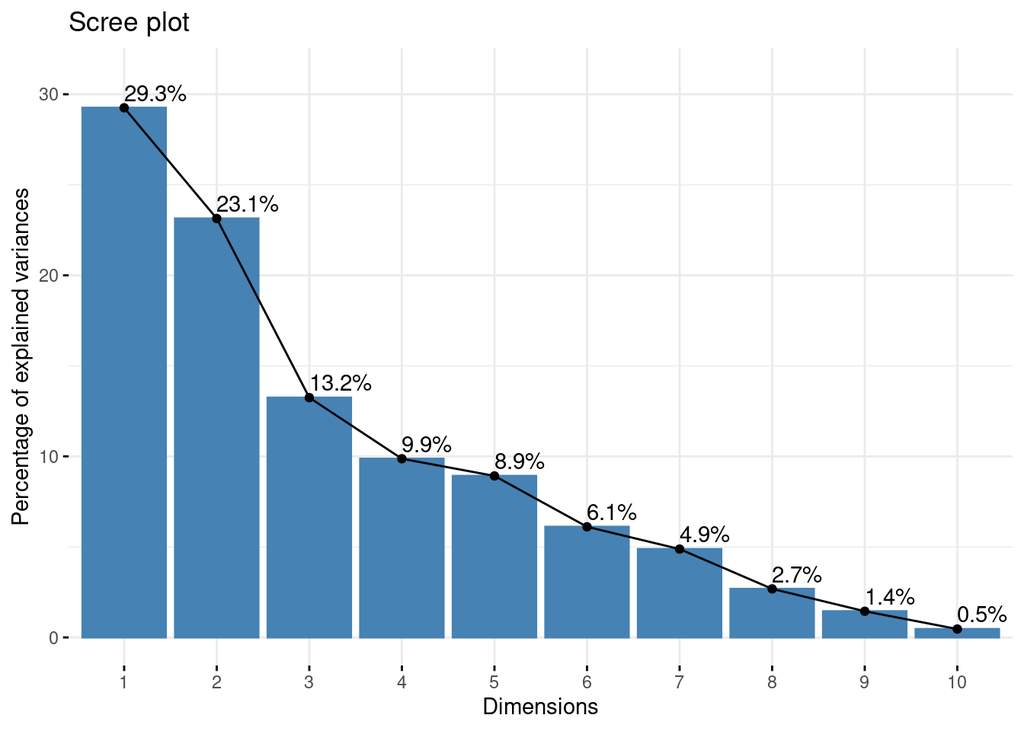

# Interpretation des axes par rapport aux modalités des variables actives

### Contirbutions :

La contribution moyenne d’une modalité d’une variable active est $100/16=6.25\%$. Nous allons donc sélectionner que les modalités contribuant au minimum à $6.25\%$ à la construction des axes.

| modalités | Dim 1 | Dim 2 | Dim 3 |
| --- | --- | --- | --- |
| Taille_1 | 12.55 | 8.70 | 8.69 |
| Taille_2 | 4.54 | 12.24 | 13.47 |
| Taille_3 | 13.32 | 0.00 | 0.01 |
| Poids_1 | 14.01 | 7.91 | 4.23 |
| Poids_2 | 1.92 | 14.79 | 1.35 |
| Poids_3 | 5.83 | 8.29 | 20.71 |
| Vélocité_1 | 1.58 | 17.37 | 3.61 |
| Vélocité_2 | 3.64 | 10.24 | 3.48 |
| Vélocité_3 | 9.76 | 1.89 | 14.14 |
| Intelligence_1 | 1.10 | 8.53 | 2.07 |
| Intelligence_2 | 3.30 | 1.12 | 13.21 |
| Intelligence_3 | 1.58 | 3.02 | 10.37 |
| Affection_1 | 10.75 | 2.10 | 1.07 |
| Affection_2 | 9.98 | 1.95 | 0.99 |
| Agressivité_1 | 2.95 | 0.89 | 1.26 |
| Agressivité_2 | 3.18 | 0.96 | 1.35 |

- AXE 1 :

  Les modalités contribuant le plus à la formation de ce premier axe sont :
  - Poids_1 (poids faible) : $14.01\%$.
  - Taille_3 (grande taille) : $13.32\%$.
  - Taille_1 (petite taille) : $12.55\%$.
  - Affection_1 (faible affection) : $10.75\%$.
  - Affection_2 (moyenne affection) : $9.98\%$.
  - Vélocité_3 (grande vitesse) : $9.76\%$.
- AXE 2 :

  Les modalités contribuant le plus à la formation de ce deuxième axe sont :
  - Vélocité_1 (faible vitesse) : $17.37\%$.
  - Poids_2 (poids moyen) : $14.79\%$.
  - Taille_2 (taille moyenne) : $12.24\%$.
  - Vélocité_2 (vitesse moyenne) : $10.24\%$.
  - Taille_1 (taille moyenne) : $8.70\%$.
  - Intelligence_1 (faible intelligence) : $8.53\%$.
  - Poids_3 (poids élevé) : $8.29\%$.
  - Poids_1 (faible poids) : $7.91\%$.
- AXE 3 :

  Les modalités contribuant le plus à la formation de ce troisième axe sont :
  - Poids_3 (poids élevé) : $20.71\%$.
  - Vélocité_3 (grande vitesse) : $14.14\%$.
  - Taille_2 (moyenne taille) : $13.47\%$.
  - Intelligence_2 (moyenne intelligence) : $13.21\%$.
  - Intelligence_3 (faible intelligence) : $10.37\%$.
  - Taille_1 (petite taille) : $8.69\%$.

On remarque que dans la construction des axes, deux modalités d’une même variable apparaissent avec de grandes contributions. C’est le cas des modalités des variables Taille, Poids, Affection, Vélocité et Intelligence. C’est une information qui pourra être exploitée plus loin avec l’analyse des coordonnées, pour déterminer les individus similaires et différents sur chaque axe.

### COS2

Le cos2 permet de mesurer le degré d’association des modalités des variables avec les dimensions. Plus il est grand, plus la modalité est bien représentée sur l’axe.

| modalités | Dim 1 | Dim 2 | Dim 3 |
| --- | --- | --- | --- |
| Taille_1 | 0.50 | 0.27 | 0.16 |
| Taille_2 | 0.16 | 0.35 | 0.22 |
| Taille_3 | 0.88 | 0.00 | 0.00 |
| Poids_1 | 0.58 | 0.26 | 0.08 |
| Poids_2 | 0.12 | 0.71 | 0.04 |
| Poids_3 | 0.21 | 0.24 | 0.34 |
| Vélocité_1 | 0.07 | 0.64 | 0.08 |
| Vélocité_2 | 0.15 | 0.34 | 0.07 |
| Vélocité_3 | 0.43 | 0.07 | 0.28 |
| Intelligence_1 | 0.05 | 0.28 | 0.04 |
| Intelligence_2 | 0.17 | 0.05 | 0.31 |
| Intelligence_3 | 0.06 | 0.09 | 0.19 |
| Affection_1 | 0.61 | 0.09 | 0.03 |
| Affection_2 | 0.61 | 0.09 | 0.03 |
| Agressivité_1 | 0.18 | 0.04 | 0.03 |
| Agressivité_2 | 0.18 | 0.04 | 0.03 |

- AXE 1 :

  Les modalités les mieux représentées sur cet axes sont :
  - Taille_3 (grande taille) : $0.88$.
  - Affection_1 (faible affection) : $0.61$.
  - Affection_2 (moyenne affection) : $0.61$.
  - Poids_1 (faible poids) : $0.58$.
  - Taille_1 (petite taille) : $0.50$.
  - Vélocité_3 (grande vitesse) : $0.43$.
- AXE 2 :

  Les modalités les mieux représentées sur cet axe sont :
  - Poids_2 (poids moyen) : $0.71$.
  - Vélocité_1 (faible vitesse) : $0.64$.
  - Taille_2 (taille moyenne) : $0.35$
  - Vélocité_2 ( vitesse moyenne) : $0.34$
- AXE 3 :

  Les modalités les mieux représentées sur cet axe sont :
  - Poids_3 (poids élevé) : $0.34$.
  - Intelligence_2 (intelligence moyenne) : $0.31$.
  - Vélocité_3 (grande vitesse) : $0.28$.
  - Taille_2 (taille moyenne) : $0.22$.

Si on essaie de cumuler les valeurs des cos2 de chaque modalité sur les 3 premiers axes retenus, on retrouver que presque toutes les modalités suivantes sont très bien représentés sur ces axes. C’est le cas des modalites Taille_1, Taille_2, Taille_3, Poids_1, Poids_2 dont la somme des cos2 est très proche de 1. Il ne faut pas oublier que ces 3 axes capturent $65.64\%$ de l’inertie totale, ce qui veut dire que la représentation des modalités ne reflète que $65.64\%$ de la réalité.

|  | Somme cos2 |
| --- | --- |
| Taille_1 | 0.9239484 |
| Taille_2 | 0.8000233 |
| Taille_3 | 0.9309283 |
| Poids_1 | 0.9343996 |
| Poids_2 | 0.9309146 |
| Poids_3 | 0.8603803 |
| Vélocité_1 | 0.8518638 |
| Vélocité_2 | 0.6890675 |
| Vélocité_3 | 0.8010004 |
| Intelligence_1 | 0.8984230 |
| Intelligence_2 | 0.7505703 |
| Intelligence_3 | 0.8669907 |
| Affection_1 | 0.7998562 |
| Affection_2 | 0.7998562 |
| Agressivité_1 | 0.8393435 |
| Agressivité_2 | 0.8393435 |

### Coordonnées des modalités des variables

Les coordonnées des modalités vont nous permettre de repérer celles qui sont corrélées négativement sur chaque axe, et aussi de construire une graphique permettant de visualiser les modalités regroupées.

| modalités | Dim 1 | Dim 2 | Dim 3 |
| --- | --- | --- | --- |
| Taille_1 | 1.19 | 0.88 | -0.67 |
| Taille_2 | 0.85 | -1.24 | 0.98 |
| Taille_3 | -0.84 | 0.00 | -0.02 |
| Poids_1 | 1.18 | 0.79 | -0.44 |
| Poids_2 | -0.33 | -0.81 | -0.19 |
| Poids_3 | -0.96 | 1.02 | 1.22 |
| Vélocité_1 | 0.35 | 1.04 | 0.36 |
| Vélocité_2 | 0.60 | -0.89 | 0.39 |
| Vélocité_3 | -0.93 | -0.36 | -0.75 |
| Intelligence_1 | -0.33 | 0.82 | -0.30 |
| Intelligence_2 | 0.47 | -0.24 | 0.63 |
| Intelligence_3 | -0.42 | -0.52 | -0.73 |
| Affection_1 | -0.81 | 0.32 | 0.17 |
| Affection_2 | 0.75 | -0.29 | -0.16 |
| Agressivité_1 | 0.41 | -0.20 | -0.18 |
| Agressivité_2 | -0.44 | 0.21 | 0.19 |

- AXE 1 :

  Cet axe oppose les modalités :
  - Taille_1 $(1.19)$ et Poids_3 $(-0.96)$.
  - Poids_1 $(1.18)$ et Taille_3 $(-0.84)$.
  - Vélocité_3 $(-0.93)$ et Poids_1 $(1.18)$, Taille_1 $(1.19)$ .
- AXE 2 :

  Cet axe oppose les modalités :
  - Affection_2 $(-0.29)$ et Agressivité_2 $(0.21)$.
  - Taille_1 $(0.88)$, Poids_1 $(0.79) et Vélocité_2 $(-0.89)$.
  - Taille_2 $(-1.24)$ et Vélocité_1(1.02)$.
  - On remarque que la coordonnée de Taille_3 sur cet axe est **nulle**.
- AXE 3:

  Cet axe oppose les modalités :
  - Affection_1 $(0.17)$ et Agressivité_1 $(-0.18)$.
  - Affection_2 $(-0.16)$ et Agressivité_2 $(0.19)$.

On remaque aussi que sur tous ces axes, il y a toujours une modalité d’une variable qui a tendance à être corrélée négativement avec les modalités de la même variable. Cette modalité qui **se disntingue** est celle qui est la **mieux représentée** sur l’axe que toutes les autres.

### Visualisation graphique des modalités

Les modalités sont projetées sur le premier plan factoriel qui retient $52.39\%$ de l’information totale.

- Sur ce plan, les modalités Taille_1, Taille_2, Poids_1, Poids_3 sont bien représentées.
  - On note aussi la proximité des modalités Taille_1 et Poids_1, Taille_3 et Vélocité_3, Agressivité_1 et Intelligence_2.
  - Le premier axe semble opposer la modalité Fonction_1 et Fonction_3.

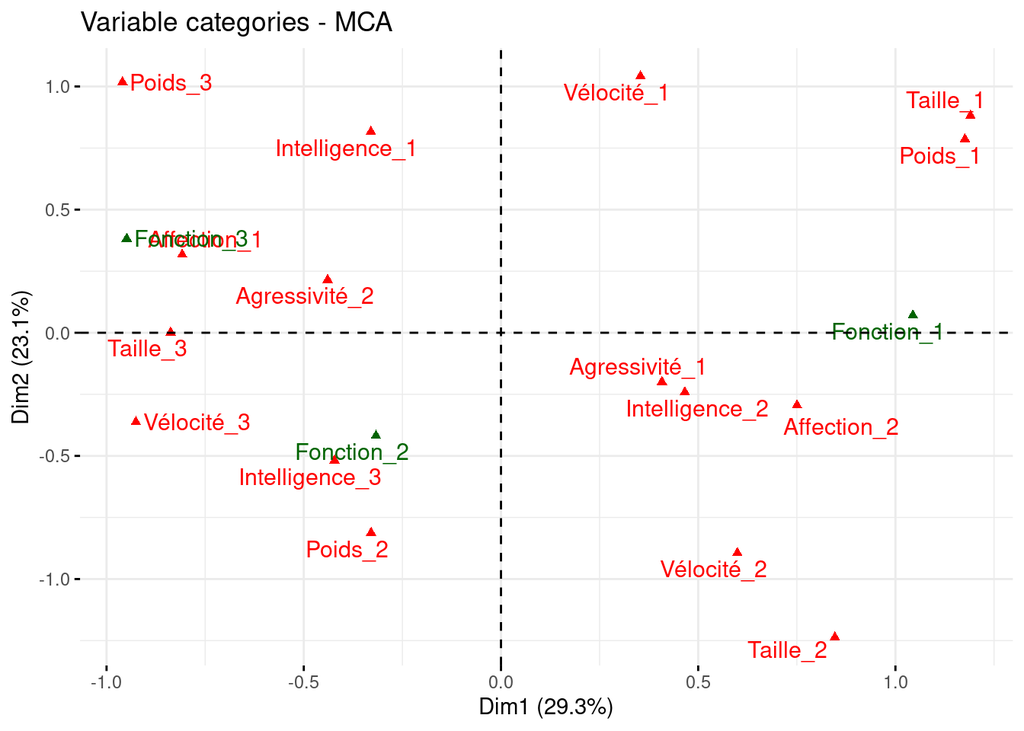

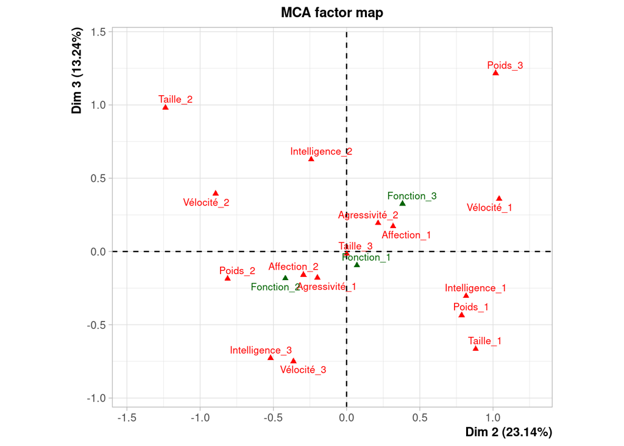

# Interpretation des axes par rapport aux variables

On visualise ici la corrélation des variables toutes modalités confondues avec le premier et le deuxième axe.

On voit que la variable Affection est très corrélée au premier axe, tandis que les variables Poids et Taille semblent fortement corrélées aux deux axes.

Les variables Intelligence et Agressivité sont faiblement corrélées aux deux axes.

La variable illustrative Fonction est fortement corrélée à l’axe1, et faiblement corrélée à l’axe2 et même l’axe3.

On observe les mêmes résultats pour les plans formés des axes 1,3 et 2,3.

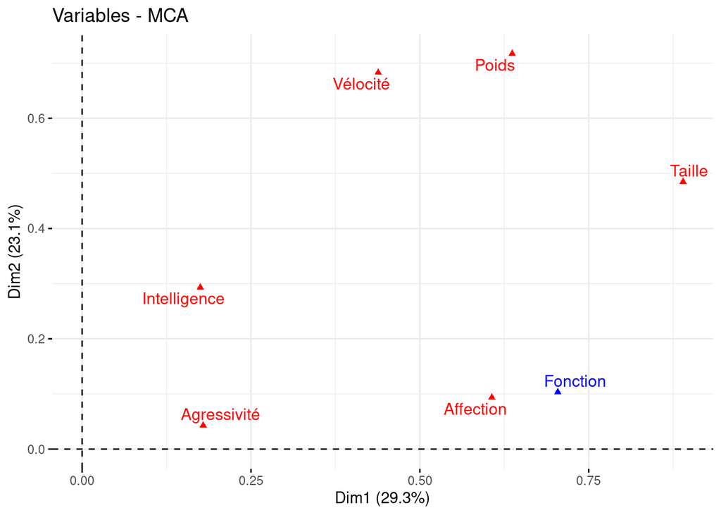

# Interprétation des axes par rapport aux individus

Il y a $27$ individus, nous allons alors mettre en évidence les contributions supérieures à $100/27=3.70$.

- AXE 1:

  Les races contribuant le plus à la formation de cet axe sont :
  - TECK : $8.17\%$
  - BULD : $8.17\%$
  - DA.L : $8.00\%$
  - DOBE : $6.13\%$
  - FX.T : $6.06\%$
  - CANI : $5.93\%$
  - FX.H : $5.83\%$
  - PEKI : $5.45\%$
  - CHIH : $5.45\%$
  - MAST : $3.95\%$
  - COCK : $4.30\%$
  - BULM : $4.19\%$
- AXE 2:

  Les races contribuant le plus à la formation de cet axe sont :
  - BASS : $11.39\%$
  - E.BR : $10.83\%$
  - LABR : $9.36\%$
  - DAL : $9.36\%$
  - MAST : $8.04\%$
  - BOXE : $7.37\%$
  - CHIH : $6.35\%$
  - PEKI : $6.35\%$
  - ST-B : $3.82\%$
- AXE 3:

  Les races contribuant le plus à la formation de cet axe sont :
  - BOXE : $7.23\%$
  - CANI : $6.64\%$
  - POIN : $6.01\%$
  - BEAU : $5.72\%$
  - B.AL : $5.72\%$
  - MAST : $5.54\%$
  - COCK : $5.18\%$
  - DAL : $4.62\%$
  - LABR : $4.62\%$
  - CHIH : $4.05\%$
  - PEKI: $4.05\%$

### COS2

Ici, on va mettre en évidence les individus les plus associés à chaque axe.

- AXE1:
  - TECK : $0.64$
  - BULD : $0.64$
  - FX.H : $0.56$
  - DOBE : $0.55$
  - D.AL : $0.54$
- AXE 2 :
  - BASS : $0.62$
  - DAL : $0.54$
  - LABR : $0.54$
  - E.BR : $0.54$
- AXE 3:
  - ST-B : $0.48$
  - T.NE : $0.35$

### Coordonnées

Pour chaque axe, on va exposer les principales race que l’axe oppose.

- AXE 1 :
  - FX.H $(-0.88)$ et FX.T $(0.89)$, CANI $(0.88)$, CHIH $(0.85)$, PEKI $(0.85)$.
  - COCK $(0.75)$ et BULM $(-0.74)$, MAST $(-0.72)$, POIN $(-0.70)$.
- AXE 2 :
  - LABR $(-0.99)$ et MAST $(0.91)$.
  - PEKI $(0.81)$, CHIH $(0.81)$ et BOXE $(-0.88)$.
- AXE 3 :
  - DAL $(0.52)$, LABR $(0.52)$, COCK $(0.56)$ et BEAU $(-0.58)$, B.AL $(-0.58)$
  - On note aussi des individus avec des coordonnées élevées comme ST-B $(0.91)$ et T.NE $(0.77)$

# Visualisation des individus et des modalités

L’avantage avec l’ACM, c’est que l’espace de représentation des variables et des individus est le même. On peut alors les visualiser directement sur le même plan pour faire une analyse symétrique. Ce n’est pas le cas avec l’AFC car les espaces des profils lignes et des profils sont construits séparément, il faut donc projeter les profils lignes dans l’espace des profils colonnes et faire une analyse asymétrique.

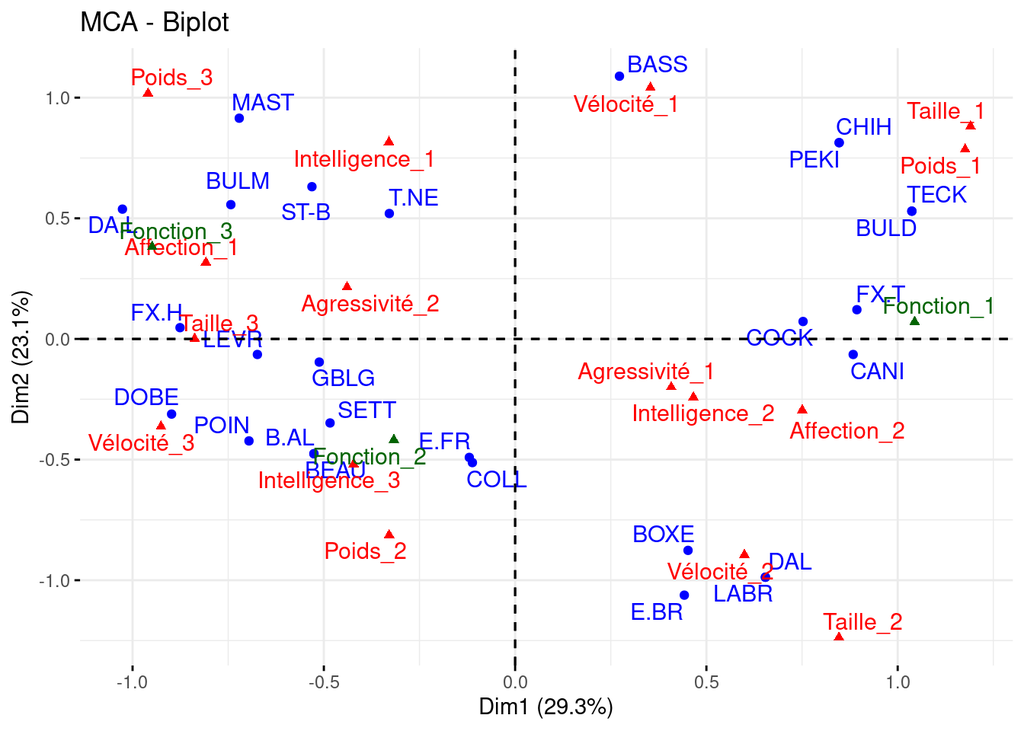

- Les chiens proches de la modalité Fonction_1, c’est à dire des chiens de compagnie ont tendance à être de petite taille, avec un petit poids, peu agressifs et moyennement affectueux. C’est le cas du pékinois, chihuahua, bull_dog, cocker, caniche, teckel, fox-terrier.
- Les chiens proches de la modalité Fonction_2, c’est à dire des chiens de chasse sont en général caractérisés par une grande vitesse, une grande taille, un poids moyen et sont très intelligents. On en cite, le berger allemand, le pointer, l’epagneul français et le levrier.
- Les chiens proches de Fonction_3, c’est à dire des chiens d’utilité ont tendance à être grands, peu affecteux, agressifs et ont un poids élevé. Par exemple, le mastiff, le bull-mastiff et le dogue allemand.
- On distingue sur le graphique un petit groupe d’individus avec une taille moyenne et une vitesse moyenne.

En résumé, la projection sur ce plan nous suggère 4 classes de races.

# Classification ascendante hiérarchique sur les axes retenus

Pour faire une classification non supervisée des races canines, nous allons effectuer une classification ascendante hiérarchique basée sur l’analyse des composantes multiples de notre jeu de données. Comme cité auparavant, l’ACM permet de transformer le caractère qualitatif des données en quantitatif.

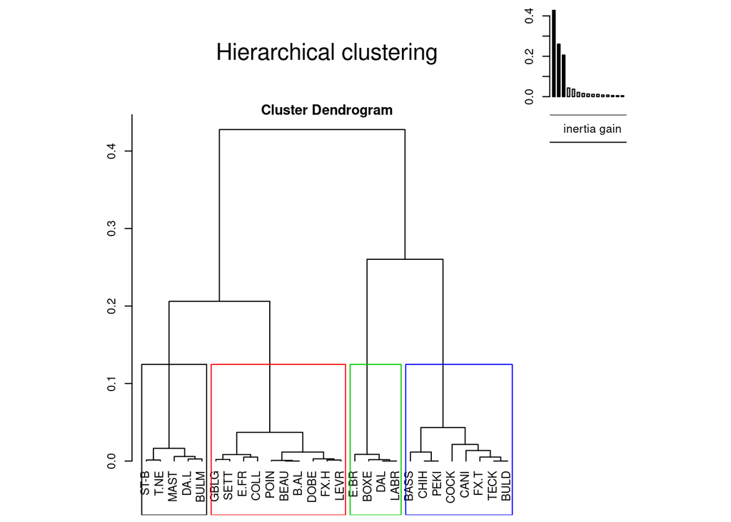

# Caractérisation des clusters

Les p-valeur des tests du khi_2 révèlent ququelles variables se repose le plus l’algorithme HCPC pour former les clusters, et aussi par quelles catégories est caractérisé chaque cluster.

### Caractérisation par les variables

C’est les variables Taille, Poids et Vélocité qui font que des individus se retrouvent ou pas dans le même cluster. Leur p-valeur sont extrémement petites $(7.37e-10)$, $(4.27e-07)$ et $(5.013e-06)$.

|  | p.value | df |
| --- | --- | --- |
| Poids | 7.377151e-10 | 6 |
| Taille | 4.275491e-07 | 6 |
| Vélocité | 5.013038e-06 | 6 |
| Fonction | 1.910968e-04 | 6 |
| Affection | 6.483613e-03 | 3 |
| Agressivité | 2.426913e-01 | 3 |
| Intelligence | 3.953448e-01 | 6 |

### Caractérisation par les catégories

La colonne Cla/Mod du tableau suivant désigne le pourcentage d’individus ayant une certaine modalité qui se retrouvent dans un cluster. Quant à la colonne Mod/Cla, elle désigne le pourcentage d’individus du cluster ayant une certaine modalité.

- Cluster 1:
  - On remaque que $100\%$ les individus de Poids_3 sont dans ce cluster.
  - On peut alors dire que les races de poids lourd et généralement de races de chiens d’utilité ont tendance à appartenir à ce cluster.
  - On remarque aussi que $62.5\%$ des individus d’utilité sont mis dans ce cluster.
  - On ne retrouve aucune race de chien de compagnie ou de chasse n’appartient à ce cluster.

|  | Cla/Mod | Mod/Cla | Global | p.value | v.test |
| --- | --- | --- | --- | --- | --- |
| Poids=Poids_3 | 100.00000 | 100 | 18.51852 | 1.238697e-05 | 4.370663 |
| Fonction=Fonction_3 | 62.50000 | 100 | 29.62963 | 6.936703e-04 | 3.392069 |
| Affection=Affection_1 | 38.46154 | 100 | 48.14815 | 1.594203e-02 | 2.410240 |
| Taille=Taille_3 | 33.33333 | 100 | 55.55556 | 3.719807e-02 | 2.083584 |
| Vélocité=Vélocité_1 | 40.00000 | 80 | 37.03704 | 5.046451e-02 | 1.956005 |
| Agressivité=Agressivité_2 | 30.76923 | 80 | 48.14815 | 1.558776e-01 | 1.419073 |

|  | Cla/Mod | Mod/Cla | Global | p.value | v.test |
| --- | --- | --- | --- | --- | --- |
| Vélocité=Vélocité_3 | 88.88889 | 88.88889 | 33.33333 | 3.499171e-05 | 4.138281 |
| Poids=Poids_2 | 64.28571 | 100.00000 | 51.85185 | 4.271548e-04 | 3.522712 |
| Taille=Taille_3 | 60.00000 | 100.00000 | 55.55556 | 1.067887e-03 | 3.272002 |
| Fonction=Fonction_2 | 55.55556 | 55.55556 | 33.33333 | 1.139343e-01 | 1.580754 |
| Intelligence=Intelligence_3 | 57.14286 | 44.44444 | 25.92593 | 1.626837e-01 | 1.396102 |
| Affection=Affection_1 | 46.15385 | 66.66667 | 48.14815 | 2.079024e-01 | 1.259354 |

|  | Cla/Mod | Mod/Cla | Global | p.value | v.test |
| --- | --- | --- | --- | --- | --- |
| Vélocité=Vélocité_2 | 62.50000 | 100 | 29.62963 | 0.0006936703 | 3.392069 |
| Taille=Taille_2 | 80.00000 | 80 | 18.51852 | 0.0013873405 | 3.197272 |
| Poids=Poids_2 | 35.71429 | 100 | 51.85185 | 0.0247987118 | 2.244524 |
| Intelligence=Intelligence_2 | 33.33333 | 80 | 44.44444 | 0.1115942029 | 1.591068 |
| Agressivité=Agressivité_1 | 28.57143 | 80 | 51.85185 | 0.2107890499 | 1.251399 |
| Affection=Affection_2 | 28.57143 | 80 | 51.85185 | 0.2107890499 | 1.251399 |

|  | Cla/Mod | Mod/Cla | Global | p.value | v.test |
| --- | --- | --- | --- | --- | --- |
| Poids=Poids_1 | 100.00000 | 100.0 | 29.62963 | 4.504352e-07 | 5.046305 |
| Taille=Taille_1 | 100.00000 | 87.5 | 25.92593 | 9.008705e-06 | 4.439694 |
| Fonction=Fonction_1 | 70.00000 | 87.5 | 37.03704 | 9.594270e-04 | 3.302162 |
| Vélocité=Vélocité_1 | 60.00000 | 75.0 | 37.03704 | 1.474275e-02 | 2.438638 |
| Affection=Affection_2 | 50.00000 | 87.5 | 51.85185 | 2.280193e-02 | 2.276737 |
| Agressivité=Agressivité_1 | 35.71429 | 62.5 | 51.85185 | 5.118196e-01 | 0.656007 |

### Représenter graphiquement l’histogramme des pourcentages des modalités dans la classe et dans l’échantillon et donner une première tendance de la typologie de chaque classe

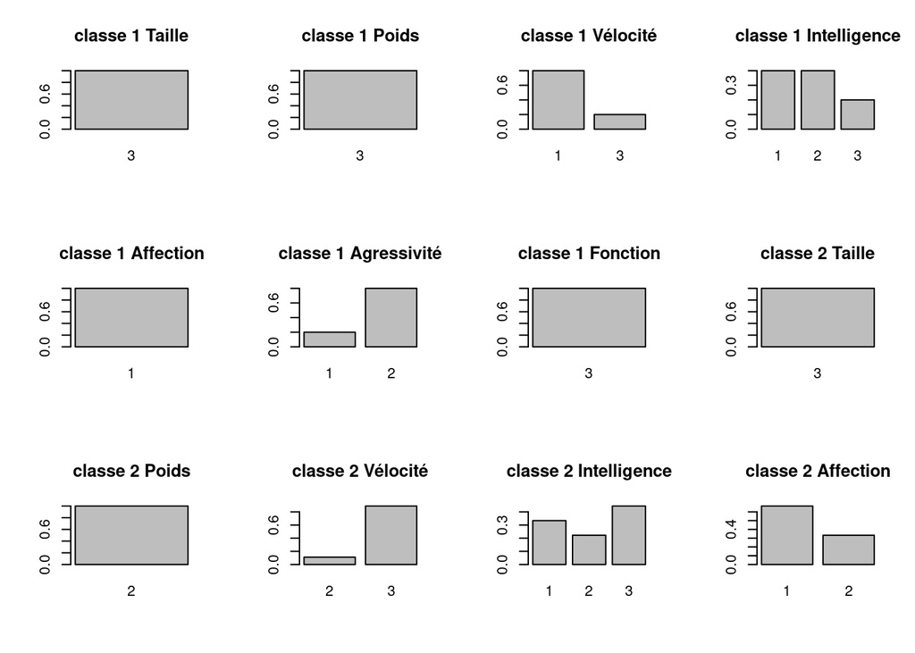

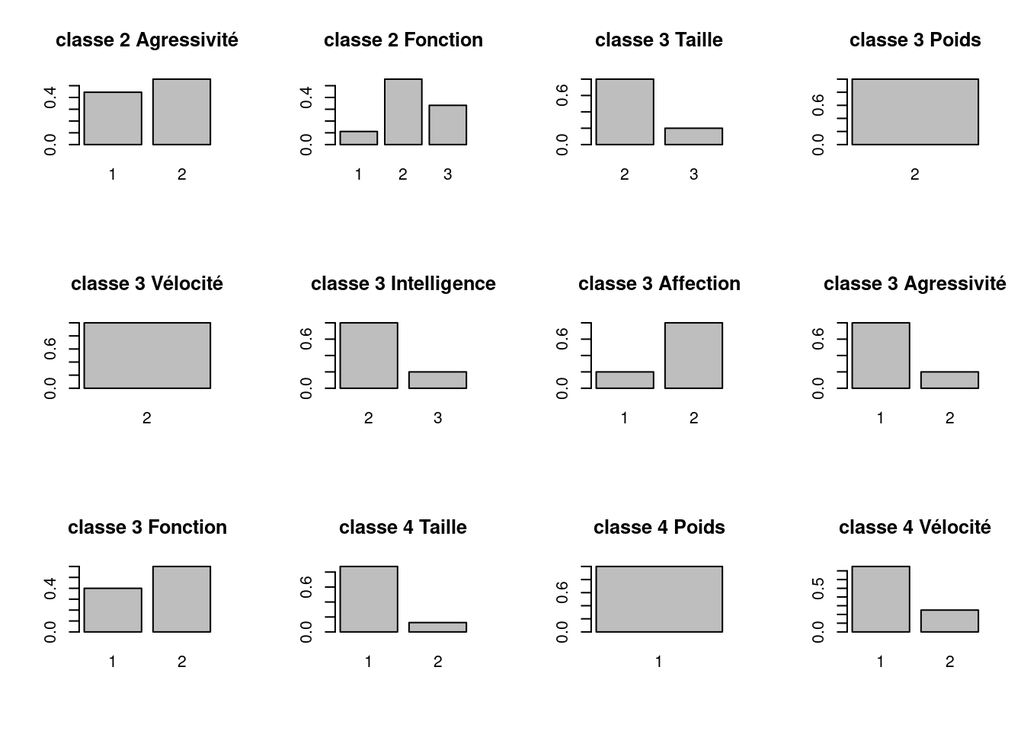

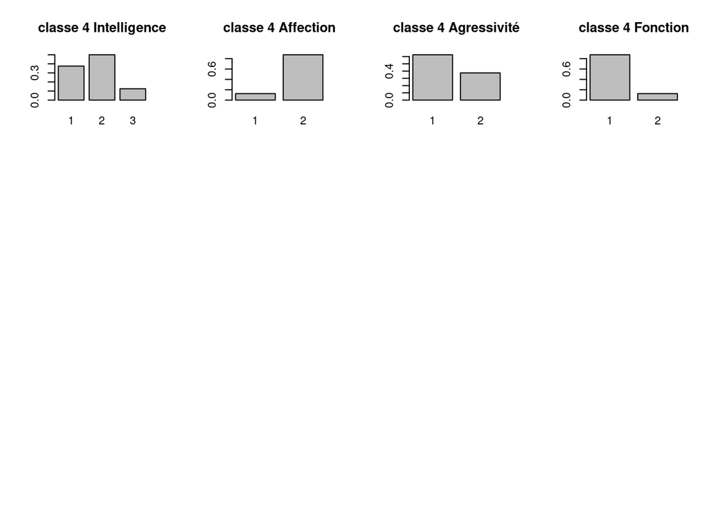

# Déduire les variables les plus significatives pour chaque cluster

# Caractériser chaque classe à l’aide des axes factoriels retenus dans la partie 1

- Les individus du cluster 1 contribuent fortement à la construction de l’axe 3 $(v.test=2.95)$ et l’axe 2 $(v.test=2.47)$.
  - Les individus du cluster 3 contribuent fortement à la formation de l’axe 3 $(v.test=2.1)$ et l’axe 2 $(v.test=1.47)$.
  - Les individus du cluster 4 contribuent fortement à la formation de l’axe 1 $(v.test=3.89)$ et l’axe 2 $(v.test=2.56)$.

### Pour chaque groupe on affiche les 5 meilleurs individus les plus proches du centre du cluster.

Ces individus sont appelés **paragones**. On donnera la distance entre chaque individu et le centre de gravité par orde ascendant.

```
## Cluster: 1
##      BULM      MAST      ST-B      T.NE      DA.L
## 0.1809080 0.2873793 0.3612294 0.4118349 0.5368331
## ------------------------------------------------------------
## Cluster: 2
##      LEVR      SETT      POIN      BEAU      B.AL
## 0.2607407 0.2714007 0.2886764 0.2924060 0.2924060
## ------------------------------------------------------------
## Cluster: 3
##      BOXE       DAL      LABR      E.BR      E.FR
## 0.2516625 0.2855829 0.2855829 0.4070605 0.6737636
## ------------------------------------------------------------
## Cluster: 4
##      TECK      BULD      FX.T      CHIH      PEKI
## 0.2239648 0.2239648 0.4185147 0.4345581 0.4345581
```

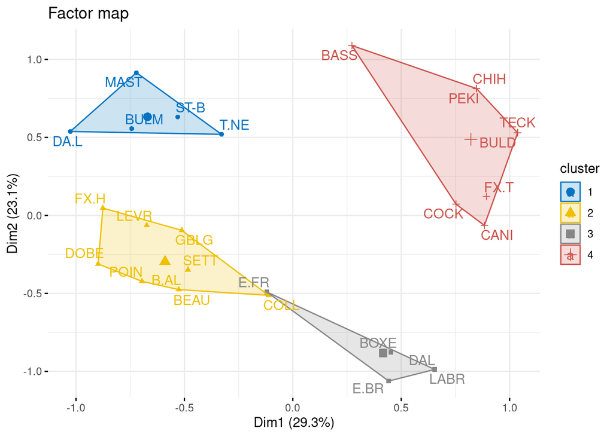

```r
fviz_cluster(hcpc,
             repel = TRUE,            # Evite le chevauchement des textes
             show.clust.cent = TRUE, # Montre le centre des clusters
             palette = "jco",         # Palette de couleurs, voir ?ggpubr::ggpar
             ggtheme = theme_minimal(),
             main = "Factor map"
             )
```